# F18 Lab Study: Preliminary Trends (For Comparison to S19)

Michael Asher

2019-04-27

# Sample

| Condition | count |
| --- | --- |
| Control | 101 |
| UVOnly | 103 |
| Competence | 107 |
| UVandCompetence | 104 |

| Female | Condition | count |
| --- | --- | --- |
| Male | Control | 44 |
| Male | UVOnly | 49 |
| Male | Competence | 52 |
| Male | UVandCompetence | 50 |
| Female | Control | 57 |
| Female | UVOnly | 54 |
| Female | Competence | 55 |
| Female | UVandCompetence | 54 |

# Model Predictions by Condition

For each outcome, I’m graphing predictions from the following model:

- Outcome scores regressed on both conditions and their interaction, controlling for baseline scores.

| DV: Exp_f | B | S.E | t | p |  |
| --- | --- | --- | --- | --- | --- |
| Exp_bZ | 0.653 | 0.043 | 17.099 | 0.000 | *** |
| Female_vs_Male | -0.069 | 0.085 | -1.815 | 0.070 | † |
| UV_vs_No | -0.001 | 0.081 | -0.030 | 0.976 |  |
| Competence_vs_No | -0.054 | 0.081 | -1.494 | 0.136 |  |
| UV_vs_No x Competence_vs_No | 0.028 | 0.162 | 0.762 | 0.447 |  |

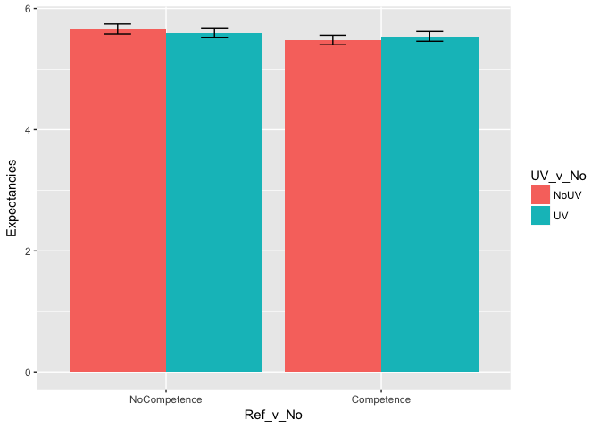

| DV: Progress_f | B | S.E | t | p |  |
| --- | --- | --- | --- | --- | --- |
| Progress_bZ | 0.535 | 0.041 | 12.376 | 0.000 | *** |
| Female_vs_Male | -0.002 | 0.083 | -0.049 | 0.961 |  |
| UV_vs_No | 0.034 | 0.080 | 0.804 | 0.422 |  |
| Competence_vs_No | -0.059 | 0.080 | -1.418 | 0.157 |  |
| UV_vs_No x Competence_vs_No | 0.013 | 0.160 | 0.318 | 0.750 |  |

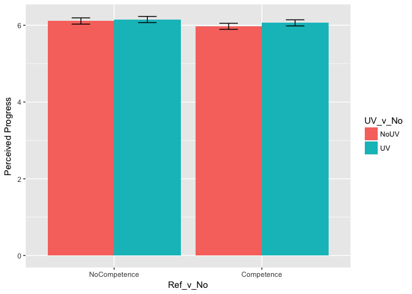

| DV: TechSI_f | B | S.E | t | p |  |
| --- | --- | --- | --- | --- | --- |
| TechSI_bZ | 0.701 | 0.042 | 19.887 | 0.000 | *** |
| Female_vs_Male | -0.040 | 0.085 | -1.141 | 0.255 |  |
| UV_vs_No | 0.061 | 0.084 | 1.763 | 0.079 | † |
| Competence_vs_No | -0.004 | 0.084 | -0.111 | 0.912 |  |
| UV_vs_No x Competence_vs_No | 0.015 | 0.168 | 0.434 | 0.665 |  |

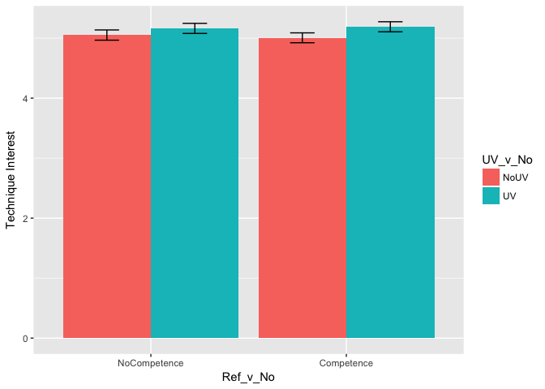

DV: totalScore

B

S.E

t

p

Score_bZ

0.727

0.245

21.201

0.000

***

Female_vs_Male

-0.083

0.491

-2.423

0.016

UV_vs_No

-0.002

0.457

-0.065

0.948

Competence_vs_No

-0.026

0.457

-0.807

0.420

UV_vs_No x Competence_vs_No

0.015

0.915

0.453

0.651

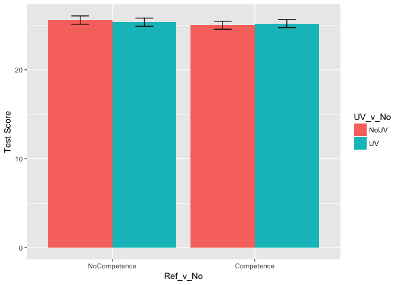

DV: AB_f

B

S.E

t

p

PCM_bZ

0.407

0.050

9.041

0.000

***

Female_vs_Male

-0.178

0.099

-3.968

0.000

***

UV_vs_No

-0.048

0.095

-1.132

0.258

Competence_vs_No

-0.101

0.095

-2.352

0.019

UV_vs_No x Competence_vs_No

0.058

0.189

1.364

0.173

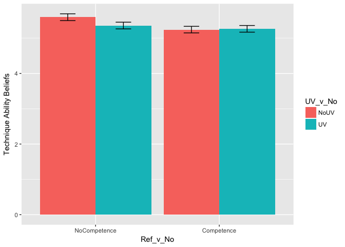

# PCM as a Moderator

| DV: Exp_f | B | S.E | t | p |  |
| --- | --- | --- | --- | --- | --- |
| Exp_bZ | 0.586 | 0.044 | 15.085 | 0.000 | *** |
| Female_vs_Male | -0.026 | 0.085 | -0.701 | 0.484 |  |
| UV_vs_No | -0.011 | 0.079 | -0.321 | 0.749 |  |
| Competence_vs_No | -0.056 | 0.079 | -1.604 | 0.109 |  |
| PCM_bZ | 0.214 | 0.043 | 5.533 | 0.000 | *** |
| UV_vs_No x Competence_vs_No | 0.038 | 0.157 | 1.083 | 0.280 |  |
| UV_vs_No x PCM_bZ | -0.006 | 0.079 | -0.165 | 0.869 |  |
| Competence_vs_No x PCM_bZ | 0.009 | 0.079 | 0.250 | 0.803 |  |
| UV_vs_No x Competence_vs_No x PCM_bZ | -0.038 | 0.157 | -1.093 | 0.275 |  |

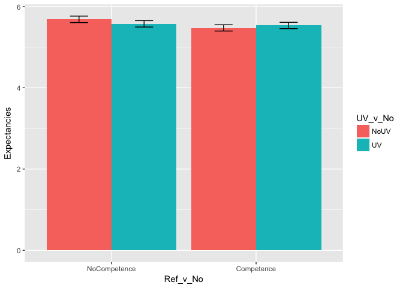

DV: Progress_f

B

S.E

t

p

Progress_bZ

0.505

0.043

11.268

0.000

***

Female_vs_Male

0.022

0.085

0.510

0.610

UV_vs_No

0.029

0.080

0.709

0.479

Competence_vs_No

-0.062

0.080

-1.504

0.133

PCM_bZ

0.112

0.044

2.470

0.014

UV_vs_No x Competence_vs_No

0.019

0.159

0.454

0.650

UV_vs_No x PCM_bZ

-0.054

0.080

-1.300

0.194

Competence_vs_No x PCM_bZ

0.031

0.080

0.740

0.460

UV_vs_No x Competence_vs_No x PCM_bZ

-0.022

0.159

-0.525

0.600

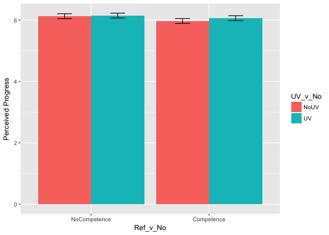

DV: Progress_BeforeTest

B

S.E

t

p

Progress_bZ

0.563

0.044

13.178

0.000

***

Female_vs_Male

0.053

0.087

1.271

0.205

UV_vs_No

-0.022

0.082

-0.547

0.584

Competence_vs_No

0.002

0.082

0.062

0.951

PCM_bZ

0.107

0.045

2.479

0.014

UV_vs_No x Competence_vs_No

0.063

0.163

1.599

0.111

UV_vs_No x PCM_bZ

-0.026

0.082

-0.653

0.514

Competence_vs_No x PCM_bZ

0.065

0.082

1.640

0.102

UV_vs_No x Competence_vs_No x PCM_bZ

-0.052

0.163

-1.320

0.188

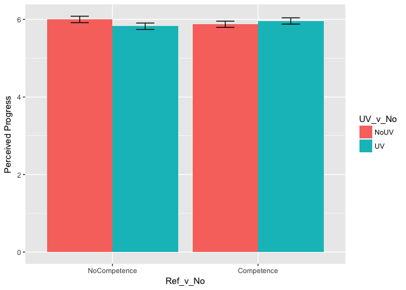

| DV: TechSI_f | B | S.E | t | p |  |
| --- | --- | --- | --- | --- | --- |
| TechSI_bZ | 0.645 | 0.043 | 18.223 | 0.000 | *** |
| Female_vs_Male | 0.017 | 0.085 | 0.494 | 0.622 |  |
| UV_vs_No | 0.051 | 0.081 | 1.516 | 0.130 |  |
| Competence_vs_No | -0.005 | 0.081 | -0.162 | 0.872 |  |
| PCM_bZ | 0.211 | 0.044 | 5.740 | 0.000 | *** |
| UV_vs_No x Competence_vs_No | 0.028 | 0.162 | 0.819 | 0.413 |  |
| UV_vs_No x PCM_bZ | 0.003 | 0.081 | 0.092 | 0.927 |  |
| Competence_vs_No x PCM_bZ | -0.044 | 0.081 | -1.306 | 0.192 |  |
| UV_vs_No x Competence_vs_No x PCM_bZ | -0.007 | 0.162 | -0.201 | 0.841 |  |

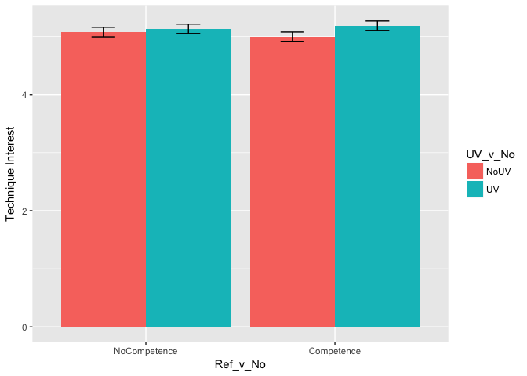

| DV: totalScore | B | S.E | t | p |  |
| --- | --- | --- | --- | --- | --- |
| Score_bZ | 0.679 | 0.266 | 18.201 | 0.000 | *** |
| Female_vs_Male | -0.067 | 0.493 | -1.936 | 0.054 | † |
| UV_vs_No | -0.003 | 0.453 | -0.094 | 0.925 |  |
| Competence_vs_No | -0.027 | 0.454 | -0.837 | 0.403 |  |
| PCM_bZ | 0.116 | 0.261 | 3.182 | 0.002 | ** |
| UV_vs_No x Competence_vs_No | 0.019 | 0.908 | 0.591 | 0.555 |  |
| UV_vs_No x PCM_bZ | 0.001 | 0.455 | 0.028 | 0.977 |  |
| Competence_vs_No x PCM_bZ | 0.053 | 0.455 | 1.656 | 0.098 | † |
| UV_vs_No x Competence_vs_No x PCM_bZ | 0.005 | 0.914 | 0.151 | 0.880 |  |

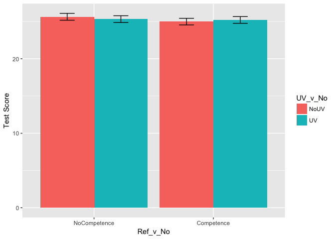

DV: AB_f

B

S.E

t

p

PCM_bZ

0.407

0.050

9.038

0.000

***

Female_vs_Male

-0.178

0.099

-3.975

0.000

***

UV_vs_No

-0.050

0.095

-1.160

0.247

Competence_vs_No

-0.097

0.095

-2.258

0.024

UV_vs_No x Competence_vs_No

0.059

0.189

1.388

0.166

PCM_bZ x UV_vs_No

0.019

0.095

0.446

0.656

PCM_bZ x Competence_vs_No

-0.030

0.095

-0.708

0.480

PCM_bZ x UV_vs_No x Competence_vs_No

-0.083

0.190

-1.935

0.054

†

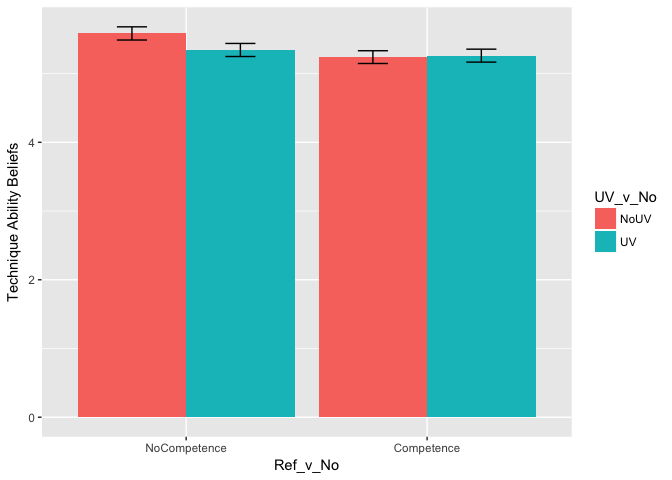

# Expectancies as a Moderator

DV: Exp_f

B

S.E

t

p

Exp_bZ

0.657

0.042

17.416

0.000

***

Female_vs_Male

-0.078

0.084

-2.067

0.039

UV_vs_No

-0.009

0.080

-0.247

0.805

Competence_vs_No

-0.061

0.080

-1.710

0.088

†

UV_vs_No x Competence_vs_No

0.029

0.159

0.800

0.424

Exp_bZ x UV_vs_No

-0.044

0.080

-1.219

0.223

Exp_bZ x Competence_vs_No

0.056

0.080

1.563

0.119

Exp_bZ x UV_vs_No x Competence_vs_No

-0.133

0.161

-3.711

0.000

***

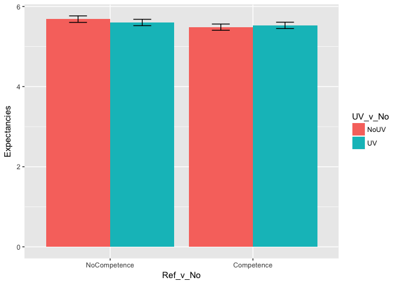

| DV: Progress_f | B | S.E | t | p |  |
| --- | --- | --- | --- | --- | --- |
| Progress_bZ | 0.478 | 0.065 | 7.108 | 0.000 | *** |
| Female_vs_Male | 0.006 | 0.084 | 0.139 | 0.890 |  |
| UV_vs_No | 0.029 | 0.079 | 0.701 | 0.483 |  |
| Competence_vs_No | -0.061 | 0.079 | -1.486 | 0.138 |  |
| Exp_bZ | 0.085 | 0.066 | 1.241 | 0.215 |  |
| UV_vs_No x Competence_vs_No | 0.019 | 0.158 | 0.471 | 0.638 |  |
| UV_vs_No x Exp_bZ | -0.038 | 0.080 | -0.910 | 0.364 |  |
| Competence_vs_No x Exp_bZ | 0.123 | 0.080 | 2.969 | 0.003 | ** |
| UV_vs_No x Competence_vs_No x Exp_bZ | -0.077 | 0.160 | -1.862 | 0.063 | † |

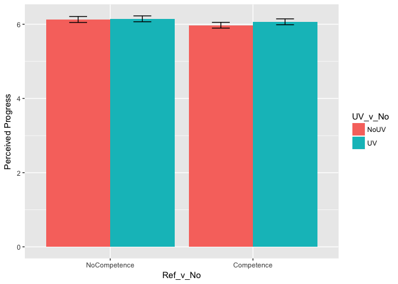

DV: Progress_BeforeTest

B

S.E

t

p

Progress_bZ

0.593

0.066

9.236

0.000

***

Female_vs_Male

0.033

0.086

0.801

0.423

UV_vs_No

-0.024

0.081

-0.603

0.547

Competence_vs_No

0.001

0.081

0.025

0.980

Exp_bZ

0.023

0.067

0.360

0.719

UV_vs_No x Competence_vs_No

0.058

0.162

1.477

0.140

UV_vs_No x Exp_bZ

-0.101

0.082

-2.537

0.012

Competence_vs_No x Exp_bZ

0.084

0.082

2.134

0.033

UV_vs_No x Competence_vs_No x Exp_bZ

-0.085

0.164

-2.133

0.034

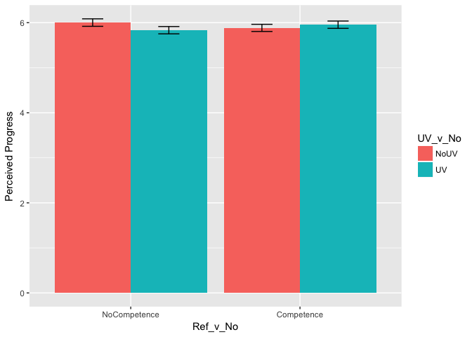

| DV: TechSI_f | B | S.E | t | p |  |
| --- | --- | --- | --- | --- | --- |
| TechSI_bZ | 0.716 | 0.047 | 18.145 | 0.000 | *** |
| Female_vs_Male | -0.049 | 0.089 | -1.325 | 0.186 |  |
| UV_vs_No | 0.059 | 0.084 | 1.689 | 0.092 | † |
| Competence_vs_No | -0.006 | 0.084 | -0.160 | 0.873 |  |
| Exp_bZ | -0.026 | 0.050 | -0.623 | 0.534 |  |
| UV_vs_No x Competence_vs_No | 0.011 | 0.168 | 0.320 | 0.749 |  |
| UV_vs_No x Exp_bZ | -0.058 | 0.085 | -1.656 | 0.098 | † |
| Competence_vs_No x Exp_bZ | -0.017 | 0.085 | -0.492 | 0.623 |  |
| UV_vs_No x Competence_vs_No x Exp_bZ | -0.027 | 0.169 | -0.764 | 0.445 |  |

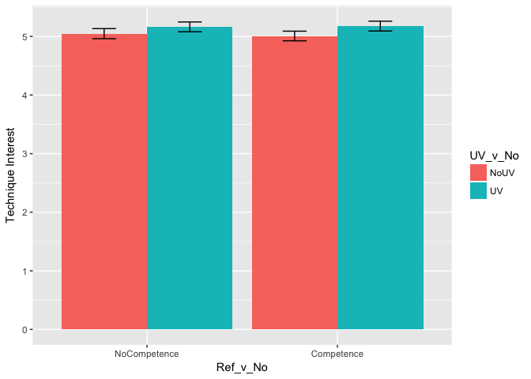

| DV: totalScore | B | S.E | t | p |  |
| --- | --- | --- | --- | --- | --- |
| Score_bZ | 0.764 | 0.300 | 18.173 | 0.000 | *** |
| Female_vs_Male | -0.098 | 0.491 | -2.860 | 0.004 | ** |
| UV_vs_No | -0.012 | 0.454 | -0.364 | 0.716 |  |
| Competence_vs_No | -0.034 | 0.454 | -1.078 | 0.282 |  |
| Exp_bZ | -0.066 | 0.298 | -1.574 | 0.116 |  |
| UV_vs_No x Competence_vs_No | 0.015 | 0.907 | 0.458 | 0.647 |  |
| UV_vs_No x Exp_bZ | -0.032 | 0.457 | -1.011 | 0.312 |  |
| Competence_vs_No x Exp_bZ | 0.020 | 0.457 | 0.620 | 0.536 |  |
| UV_vs_No x Competence_vs_No x Exp_bZ | -0.095 | 0.916 | -2.971 | 0.003 | ** |

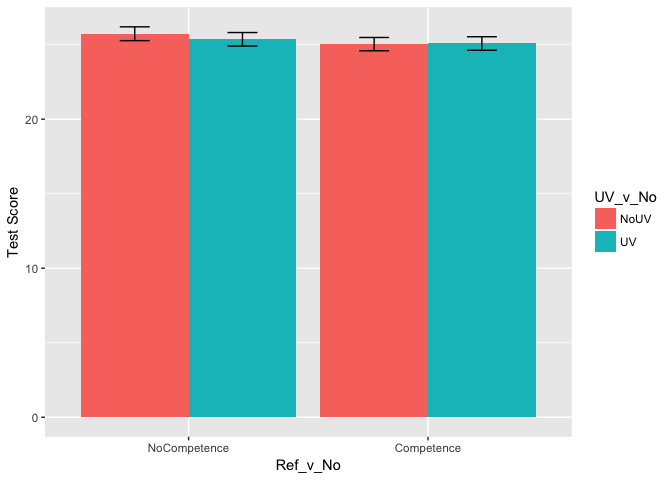

DV: AB_f

B

S.E

t

p

PCM_bZ

0.252

0.045

6.219

0.000

***

Female_vs_Male

-0.068

0.088

-1.713

0.087

†

UV_vs_No

-0.016

0.081

-0.426

0.670

Competence_vs_No

-0.072

0.081

-1.966

0.050

Exp_bZ

0.507

0.045

12.425

0.000

***

UV_vs_No x Competence_vs_No

0.042

0.162

1.143

0.254

UV_vs_No x Exp_bZ

-0.015

0.081

-0.398

0.691

Competence_vs_No x Exp_bZ

0.009

0.081

0.250

0.802

UV_vs_No x Competence_vs_No x Exp_bZ

-0.050

0.164

-1.337

0.182

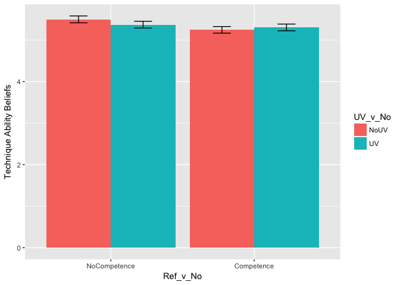